# Age-flies analysis

David Gorelik

13/11/2021

# Results

## Setup

### functions

```r
meanFunction <- function(x){
  return(data.frame(y=round(mean(x),2),label=round(mean(x,na.rm=T),2)))}

sampleName_find<-function(string,pattern = pattren_name) {
  return (strsplit(string, pattren_name)[[1]][1])
}

read_file_in_folder <-function(folder, file_name=A2G_fileName, col_names = BED_colNames){
  filePath = paste0(folder,'/',file_name)
  return(read.delim(file = filePath, col.names = col_names))
}

save_pheatmap_pdf <- function(x, filename, width=12, height=8) {
  stopifnot(!missing(x))
  stopifnot(!missing(filename))
  pdf(filename, width=width, height=height)
  grid::grid.newpage()
  grid::grid.draw(x$gtable)
  dev.off()
}

draw_colnames_45 <- function (coln, gaps, ...) {
  coord = pheatmap:::find_coordinates(length(coln), gaps)
  x = coord$coord - 0.5 * coord$size
  res = textGrob(coln, x = x, y = unit(1, "npc") - unit(3,"bigpts"), vjust = 0.5, hjust = 1, rot = 45, gp = gpar(...))
  return(res)
}
normalize <- function(x){return((x- min(x)) /(max(x)-min(x)))}
normalize_ver2 <- function(x){return((x- min(na.omit(x))) /(max(x)-min(na.omit(x))))}
```

```r
knwon_analysis_per_group <- function(filenames,group,min_edited,min_mismatches, flagCoverage =T)  {
  #filenames <- filenames_second
  #group <- groups_separated[2]
  #min_edited <- args$min_edited2

  # filenames = list_files_group
  # group =group
  # min_edited = min_edited_samples
  # min_mismatches = 10
  # flagCoverage =T
  all_csv <- lapply(filenames, function(x){

    current_name <- sub("^([^.]*).*", "\\1", basename(as.character(x)))
    names <-c("Region","Position","Reference","Strand",
              paste(group,current_name,"Coverage.q25",sep="_"),
              "MeanQ",
              paste(group,current_name,"BaseCount.A.C.G.T.",sep="_"),"AllSubs","Frequency")

    dat <- read.csv(file=x,header=T,sep="\t", stringsAsFactors=F,col.names = names)[,c(1,2,5,7)]
    if(nrow(dat)!=0){
      dat$Region <- paste(dat$Region,dat$Position)
      dat <- dat[,-c(2)]
      #dat <-dat[dat[,2]>= min_coverage,]    #take only reads where coverage > 10

      if(flagCoverage){
      dat <-dat[dat[,2]>= min_coverage,]
      }
      if(nrow(dat) == 0){return()}
      dat[,3] <- do.call(rbind,lapply(dat[,3], FUN = function(y){
        as.numeric(strsplit(y,split=",",fixed=T)[[1]][3])}))

      #take the site that surpass amount of mismatches
      dat <- dat[dat[,3] >= min_mismatches,]

      #take number of edit sites devided by num_of_reads, which must be >10
      #tmp_dat <-dat
      dat[,3] <- dat[,3]/as.numeric(dat[,2])
      dat[,-c(2)]
    }
  })

  all_csv_coverage <- lapply(filenames, function(x){
    # print(x)
    #group <- "control"
    #min_edited <- 1
    #x<-filenames[1]
    current_name <- sub("^([^.]*).*", "\\1", basename(as.character(x)))
    names <-c("Region","Position","Reference","Strand",
              paste(group,current_name,"Coverage.q25",sep="_"),
              "MeanQ",
              paste(group,current_name,"BaseCount.A.C.G.T.",sep="_"),"AllSubs","Frequency")

    dat <- read.csv(file=x,header=T,sep="\t", stringsAsFactors=F,col.names = names)[,c(1,2,5,7)]
    if(nrow(dat)!=0){
      dat$Region <- paste(dat$Region,dat$Position)
      dat <- dat[,-c(2)]
      if(flagCoverage){
        dat <-dat[dat[,2]>= min_coverage,]    #take only reads where coverage > 10
      }
      if(nrow(dat) == 0){return()}

      dat[,3] <- do.call(rbind,lapply(dat[,3], FUN = function(y){
        as.numeric(strsplit(y,split=",",fixed=T)[[1]][3])}))

      #take the site that surpass amount of mismatches
      dat <- dat[dat[,3] >= min_mismatches,]
      if(nrow(dat) ==0) {print("check manually the filter minmismatch, no sites")}

      #take number of edit sites devided by num_of_reads, which must be >10
      #tmp_dat <-dat
      dat[,-c(3)]
    }
  })

  #add the amount of A
  all_csv_A <- lapply(filenames, function(x){
    #group <- "control"
    #min_edited <- 1
    #x<-filenames[1]
    current_name <- sub("^([^.]*).*", "\\1", basename(as.character(x)))
    names <-c("Region","Position","Reference","Strand",
              paste(group,current_name,"Coverage.q25",sep="_"),
              "MeanQ",
              paste(group,current_name,"BaseCount.A.C.G.T.",sep="_"),"AllSubs","Frequency")

    dat <- read.csv(file=x,header=T,sep="\t", stringsAsFactors=F,col.names = names)[,c(1,2,5,7)]
    if(nrow(dat)!=0){
      dat$Region <- paste(dat$Region,dat$Position)
      dat <- dat[,-c(2)]

      if(flagCoverage){
        dat <-dat[dat[,2]>= min_coverage,]    #take only reads where coverage > 10
      }
      if(nrow(dat) == 0){return()}

      dat[,4] <- do.call(rbind,lapply(dat[,3], FUN = function(y){
        as.numeric(strsplit(y,split=",",fixed=T)[[1]][3])}))

      dat[,3] <- do.call(rbind,
                         lapply(dat[,3], FUN = function(y){
        as.numeric(
          strsplit(
          strsplit(y,split=",",fixed=T)[[1]][1],
          split="[",fixed=T)[[1]][2]
          )
        }))

      names(dat)[4] <- paste0(names(dat)[2],"G")
      names(dat)[3] <- paste0(names(dat)[2],"A")
      #take the site that surpass amount of mismatches
      dat <- dat[dat[,4] >= min_mismatches,]


      #take number of edit sites devided by num_of_reads, which must be >10
      #tmp_dat <-dat
      dat[,-c(2,4)]
    }
  })

  #add the amount of G
  all_csv_G <- lapply(filenames, function(x){
    #group <- "control"
    #min_edited <- 1
    #x<-filenames[1]
    current_name <- sub("^([^.]*).*", "\\1", basename(as.character(x)))
    names <-c("Region","Position","Reference","Strand",
              paste(group,current_name,"Coverage.q25",sep="_"),
              "MeanQ",
              paste(group,current_name,"BaseCount.A.C.G.T.",sep="_"),"AllSubs","Frequency")

    dat <- read.csv(file=x,header=T,sep="\t", stringsAsFactors=F,col.names = names)[,c(1,2,5,7)]
    if(nrow(dat)!=0){
      dat$Region <- paste(dat$Region,dat$Position)
      dat <- dat[,-c(2)]

      if(flagCoverage){
        dat <-dat[dat[,2]>= min_coverage,]    #take only reads where coverage > 10
      }
      if(nrow(dat) == 0){return()}

      dat[,4] <- do.call(rbind,lapply(dat[,3], FUN = function(y){
        as.numeric(strsplit(y,split=",",fixed=T)[[1]][3])}))

      dat[,3] <- do.call(rbind,
                         lapply(dat[,3], FUN = function(y){
                           as.numeric(
                             strsplit(
                               strsplit(y,split=",",fixed=T)[[1]][1],
                               split="[",fixed=T)[[1]][2]
                           )
                         }))

      names(dat)[4] <- paste0(names(dat)[2],"G")
      names(dat)[3] <- paste0(names(dat)[2],"A")
      #take the site that surpass amount of mismatches
      dat <- dat[dat[,4] >= min_mismatches,]

      #tmp_dat <-dat
      dat[,-c(2,3)]
    }
  })

  # combine into a single dataframe
  all_csv <- Reduce(function(dtf1, dtf2) merge(x = dtf1, y = dtf2,
                                               by.x = "Region", by.y ="Region" ,all=T),
                    Filter(Negate(is.null), all_csv))

  all_csv_coverage <- Reduce(function(dtf1, dtf2) merge(x = dtf1, y = dtf2,
                                                        by.x = "Region", by.y ="Region" ,all=T),
                             Filter(Negate(is.null), all_csv_coverage) )
  #Num A, G
  all_csv_A <- Reduce(function(dtf1, dtf2) merge(x = dtf1, y = dtf2,
                                                        by.x = "Region", by.y ="Region" ,all=T),
                             Filter(Negate(is.null), all_csv_A) )

  all_csv_G <- Reduce(function(dtf1, dtf2) merge(x = dtf1, y = dtf2,
                                                        by.x = "Region", by.y ="Region" ,all=T),
                             Filter(Negate(is.null), all_csv_G) )

  #merge the two data frames
  all_csv_combined <- left_join(all_csv,all_csv_coverage, by='Region')
  all_csv_combined <- left_join(all_csv_combined,all_csv_A, by='Region')
  all_csv_combined <- left_join(all_csv_combined,all_csv_G, by='Region')

  all_csv_combined <- all_csv_combined[apply(all_csv_combined[,1:ncol(all_csv)], 1,
                                             function(x) sum(is.na(x)))<=length(filenames)-min_edited,]

  #all_csv_tmp <- all_csv

  #get mean of the %editing
  means<-paste("mean",group,sep="_")
  medians<-paste("median",group,sep="_")
  #all_csv[[means]] <- rowMeans(all_csv[,-c(1)],na.rm = T)

  lst_rowMeans <- rowMeans(all_csv_combined[,c(2:ncol(all_csv))],na.rm = T)
  lst_rowMedians <- rowMedians(as.matrix(all_csv_combined[,c(2:ncol(all_csv))]), na.rm = T)

  all_csv_combined[[means]] <- lst_rowMeans
  all_csv_combined[[medians]] <- lst_rowMedians
  #Debug
  #all_csv <- all_csv_tmp

  return(all_csv_combined)
}
```

themes to use with ggplot2

```r
themes_ggplot <- theme_bw() +
  theme(panel.grid.major = element_blank(), panel.grid.minor = element_blank())+
  font("xlab", size = 12, color = "black", face = "bold") +
  font("ylab", size = 12, color = "black", face = "bold") +
  font("title", size = 14, color = "black", face = "bold")+
  font("legendtitle", size = 12, color = "black", face = "bold")+
  font("legendtext", size = 12, color = "black")+
  font("xy.text", size = 12, color = "black")+
  font("ylab", size = 12, color = "black", face = "bold") +
  font("xlab", size = 12, color = "black", face = "bold") +
  theme(strip.text.x = element_text( size = 12, color = "black", face = "bold"))+
  theme(strip.text.y = element_text( size = 12, color = "black", face = "bold"))+
  theme(legend.position='top')
```

### SRA

```r
OUT_DIR <- "results/Cornell/known/"
sra_table_path <- "raw/Cornell/SraRunTable.txt"
dbgap_data_path <- "raw/Cornell/combined_sample_subject_attribute.csv"
dir.create(OUT_DIR)
#read and combine information table together
dbgap_table <- read.csv(file= dbgap_data_path, stringsAsFactors=FALSE)
sra_table_part <- read.csv(file= sra_table_path, stringsAsFactors=FALSE)
sra_table <- left_join(dbgap_table,sra_table_part,by = c("BioSample.Accession"="BioSample"))

#Create a new column of controls and COVID-19 patients, based on viral load values.
sra_table$Covid_Load <- NA
sra_table$Covid_Load[sra_table$VIRAL_LOAD == "None"] <- "Control"
sra_table$Covid_Load[sra_table$VIRAL_LOAD == "Low"] <- "COVID-19"
sra_table$Covid_Load[sra_table$VIRAL_LOAD == "Medium"] <- "COVID-19"
sra_table$Covid_Load[sra_table$VIRAL_LOAD == "High"] <- "COVID-19"
sra_table$Covid_Load[sra_table$VIRAL_LOAD == "OtherViralInfection"] <- "Other"

#take only required columns
vector_sra_colmns <- c("RT_PCR","VIRAL_LOAD","Covid_Load")
sra_table <- dplyr::select(sra_table,c("Run",vector_sra_colmns))
```

```
## Note: Using an external vector in selections is ambiguous.
## ℹ Use `all_of(vector_sra_colmns)` instead of `vector_sra_colmns` to silence this message.
## ℹ See <https://tidyselect.r-lib.org/reference/faq-external-vector.html>.
```

```r
#orgenize the values in each column
sra_table$RT_PCR <- factor(sra_table$RT_PCR,levels = c("NotDetected","Detected"))
sra_table$VIRAL_LOAD <- factor(sra_table$VIRAL_LOAD ,levels = c("None","Low", "Medium", "High", "OtherViralInfection"))
sra_table$Covid_Load <- factor(sra_table$Covid_Load ,levels = c("Control","COVID-19", "Other"))


#take only the required column
sra_table$group <- sra_table$Covid_Load
sra_table$group <- gsub('-','.',sra_table$group) # so there whould be no problems with '-' in COVID-19
sra_table_known <- select(sra_table, "Run", "group" )

#daclare the comparisons
my_comparisons_all <- list(c("Control","COVID.19"), c("COVID.19","Other"), c("Control","Other") )
```

## Analysis

### Known raw

```r
Known_dir_path <-"raw/Cornell/known/"
min_edited_samples <- 10
min_coverage <- 20 #minimal coverage of AG in this location
min_mismatches <- 0 #minimal amount of mismatches

flagCoverage =T #remove low edited samples
```

read all the files for the analsys

```r
all_files_path <- list.files(path=Known_dir_path, full.names=T, recursive=T, pattern = "\\.REDItoolKnown.out.tab$" )
all_files_names <- unlist(lapply(all_files_path, function(x) strsplit(basename(x),'.',fixed = T)[[1]][1]))
files_table <- data.frame(Run = all_files_names,
                             Path = all_files_path)
```

now let’s combine the tables

```r
files_table <- files_table[files_table$Run %in% sra_table_known$Run,]
df_files <- left_join(files_table, sra_table_known, by="Run")

#remove the Other viruses group to focus only on COVID-19
df_files <- df_files[df_files$group != "Other",]
```

Script that read all the files from the same group to one table.

```r
list_df_analysis <- list()
df_sra_keys <- sra_table[c("Run")]
df_files_group <- df_files
df_files_group <- left_join(df_files_group,df_sra_keys)
for(group in unique(df_files$group)){
  print(group)
  list_files_group <- na.omit(df_files$Path[df_files$group == group])

  analysis <- knwon_analysis_per_group(filenames = list_files_group,
                                       group =group,
                                       min_edited = min_edited_samples,
                                       min_mismatches = min_mismatches,
                                       flagCoverage = flagCoverage)

  df_files_group <- df_files[df_files$group == group,]

  list_df_analysis[[length(list_df_analysis)+1]] <- analysis
}
```

```
## [1] "Control"
## [1] "COVID.19"
```

### Known combination {.tabset .tabset-pills}

Now… let’s read other parameters.

```r
GabaiSites_sites_list <- "raw/Cornell/allTissues_filtered_newBlat_61_94_newClust_clust_100_wTissueNumber_wSums_summary_editLvl0.01inOneTissue_allFields_NoWxsLvl0.001_tissues_maxEditLvl_Min100reads_noRRnaRep.txt"
GabaiSites_sites_base <- "raw/Cornell/Orshay_AllSites_list.bed"

df_GabaiSites <- read.csv(GabaiSites_sites_list,sep="\t",header = F)
important_cols <- c("Chr","Start","End","Alt","expression","Strand",  "gene","Data","annot")
colnames(df_GabaiSites)[seq(length(important_cols))] <- important_cols
df_GabaiSites$Region <- paste0(df_GabaiSites$Chr," ",df_GabaiSites$End)
df_GabaiSites_short <- df_GabaiSites[,-c(grep("V",colnames(df_GabaiSites)))]
df_GabaiSites_short$Data <- gsub(",","_",df_GabaiSites_short$Data)
df_GabaiSites_short$expression <- gsub(",","_",df_GabaiSites_short$expression)


df_GabaiSites_sites_base <- read.csv(GabaiSites_sites_base, sep = "\t", col.names = c("chr","pos","starnd","base","gene"))
GabaiSites_AG_base <- df_GabaiSites_sites_base %>% filter(base == "AG") %>% mutate(label = paste(.$chr, .$pos)) %>% .$label
```

Let’s print all the groups combinations

```r
groups <-  unique(df_files$group)
for(i in seq(1,length(groups), by=1)){
  if (i == length(groups)) break
  for(j in seq(i + 1,length(groups), by=1)){
    #print(paste(i,j))
    group_name <- paste(groups[i],groups[j],sep=':')
    print(group_name)
  }
}
```

```
## [1] "Control:COVID.19"
```

Now let’s declare the parameters

```r
allowed_comparisons <- c(#"COVID.19:Other",
                         "Control:COVID.19"
                         #"Other:Control"
                         )

minimal_editing_one_group <- 0.05
minimal_editing_all <- 0.05
cov_value <- 0.2
statistical_exam <- "wilcox.test"
corr_method <- "pearson"

flag_checking_if_one_table_empty <- T
flag_checking_allowed_comparisons <- T
flag_checking_exclude_than_0_in_both_means <- T
```

Now we have all the tables in one list. but we do want to analyse every 2 tables together: we use tringle upper matrice to cover all groups.

```r
df_combined_sites <- data.frame(Region=character(0))
groups <-  unique(df_files$group)
comparison <- 0

for(i in seq(1,length(list_df_analysis), by=1)){
  if (i == length(list_df_analysis)){break}
   for(j in seq(i + 1,length(groups), by=1)){
    #print(paste(i,j))
    group_name <- paste(groups[i],groups[j],sep=':')

    #perform check if dataset is empty
    if (flag_checking_if_one_table_empty){
      if (nrow(list_df_analysis[[i]]) ==0 | nrow(list_df_analysis[[j]]) ==0 ){
        print(paste("BEAWRE", group_name,"resulted with no rows"))
        next
    }}

    if (flag_checking_allowed_comparisons){
      if (! group_name  %in% allowed_comparisons) {next}
    }

    #merge group, and get difference in mean
    df_merged <- merge(list_df_analysis[[i]],list_df_analysis[[j]], by="Region",all=F)

    #filter only AG sites
    df_merged <- df_merged %>% filter(df_merged$Region %in% GabaiSites_AG_base)

    #get only rows that didnt heave 0 in both means
    if(flag_checking_exclude_than_0_in_both_means){
      df_merged <- df_merged[apply(df_merged[,grep("^mean", colnames(df_merged))], 1,
                                       function(x) {!(as.numeric(x[1])==0 & as.numeric(x[2])==0)}),]
    }

    #difference between means
    df_merged$diff_mean_second_first <- apply(df_merged[,grep("^mean", colnames(df_merged))],
                                                 1,
                                                 function(x) {
                                                   round(
                                                     #abs(
                                                       as.numeric(x[1])-as.numeric(x[2]),
                                                       #),
                                                     digits = 3)
                                                   })

    result_one_sample_t.test <- t.test(df_merged$diff_mean_second_first)
    print(paste("All sitesGroup:",group_name,"Number of sites:",
                length(df_merged$diff_mean_second_first),
                result_one_sample_t.test[[3]]))

    #get p-value and FDR
    #colnames(df_merged[,column_first])

    #select the coulmns
    # column_first<- grep(paste0("^",as.character(groups[i]),'_'), colnames(df_merged))
    # column_second<- grep(paste0("^",as.character(groups[j]),'_'), colnames(df_merged))
    # #exclude coverage coulmns
    # column_first <- column_first[-which(column_first %in% grep('Coverage', colnames(df_merged)))]
    # column_second <- column_second[-which(column_second %in% grep('Coverage', colnames(df_merged)))]
    #

    regex_1 <- paste0("^",as.character(gsub(" ",".",groups[i])),"_[A-Z,0-9]*_BaseCount.A.C.G.T.")
    # regex_2 <- paste0("^",as.character(gsub(" ",".",gsub("\\.","-",groups[j]))),"_[A-Z,0-9]*_BaseCount.A.C.G.T.")
    regex_2 <- paste0("^",as.character(gsub(" ",".", groups[j])),"_[A-Z,0-9]*_BaseCount.A.C.G.T.")

    column_first <- grep(regex_1, colnames(df_merged))
    column_second <- grep(regex_2, colnames(df_merged))


    df_merged$sum_edited_samples <- apply(df_merged[,c(column_second,column_first)],
                                          1,
                                          function(x) length(column_second)+length(column_first)-sum(is.na(x)))


    #first of all: retain only the samples that sourpuss the amount of edited samples
    df_merged <- df_merged[apply(df_merged[c(column_first)],1, function(x) {
      length(x) - sum(is.na(x)) >= min_edited_samples }),]
    df_merged <- df_merged[apply(df_merged[c(column_second)],1, function(x) {
      length(x) - sum(is.na(x)) >= min_edited_samples }),]

    if(nrow(df_merged) ==0) {
      print(paste("BEAWRE", group_name,"resulted with no rows after filtering. consider lower the filters"))
      next
      }

    if(nrow(df_merged)>1){
    result_one_sample_t.test <- t.test(df_merged$diff_mean_second_first)
    print(paste("Servived sitesGroup:",group_name,"Number of sites:",
                length(df_merged$diff_mean_second_first),result_one_sample_t.test[[3]]))
    }

    if(statistical_exam == "t.test") {
    df_merged$p_val <- apply(df_merged,1, function(x) {
      tryCatch(  expr = {
            as.numeric(unlist(
              t.test(as.numeric(x[c(column_first)]),
                     as.numeric(x[c(column_second)]),
              )[[3]]))
            },
            error = function(e){NA
              #DEBUG print(paste0("Error when comparing: ",i,", ", j, "-",
              # group_name,". t.test on: (1).",x[c(column_first)],". (2).",x[c(column_second)],"."))
              }, warning = function(w){}, finally = {}) })
    }else if(statistical_exam == "wilcox.test") {
      df_merged$p_val <- apply(df_merged,1, function(x) {
      tryCatch(  expr = {
            as.numeric(unlist(
              wilcox.test(as.numeric(x[c(column_first)]),
                     as.numeric(x[c(column_second)]),
              )[[3]]))
            },
            error = function(e){NA
              #DEBUG print(paste0("Error when comparing: ",i,", ", j, "-",
              # group_name,". t.test on: (1).",x[c(column_first)],". (2).",x[c(column_second)],"."))
              }, warning = function(w){}, finally = {}) })
    }


    df_merged$pearson <- apply(df_merged,1, function(x) {
      tryCatch(  expr = {
        as.numeric(unlist(
          cor(as.numeric(x[c(column_first)]),as.numeric(x[c(column_second)]), method = corr_method)
          [[1]]))
      }, error = function(e){NA
        # print(paste0("Error when comparing: ",i,", ", j, "-",
        # group_name,". t.test on: (1).",x[c(column_first)],". (2).",x[c(column_second)],"."))
      }, warning = function(w){}, finally = {})  })


    df_merged$p_val <- NA
      for (row in seq(1,nrow(df_merged))) {
        #df_merged[row,"p_val"] <- as.numeric(unlist(df_merged[row,"p_val"]))
        x <- df_merged[row,]
        df_merged$p_val[row] <- wilcox.test(
          as.numeric(na.omit(as.numeric(x[c(column_first)]))),
          as.numeric(na.omit(as.numeric(x[c(column_second)])))
                     )[[3]]
      }
    #FDR
    df_merged$FDR_full <- p.adjust(df_merged$p_val,method="fdr")

    #okay.... let's change the names
    names(df_merged)[names(df_merged)=="diff_mean_second_first"] <- paste('diff',group_name,sep = ':')
    names(df_merged)[names(df_merged)=="sum_edited_samples"] <- paste('sum_edited',group_name,sep = ':')
    names(df_merged)[names(df_merged)=="p_val"] <- paste('p_val',group_name,sep = ':')
    names(df_merged)[names(df_merged)=="pearson"] <- paste('pearson',group_name,sep = ':')
    names(df_merged)[names(df_merged)=="FDR_full"] <- paste('FDR_full',group_name,sep = ':')

    #Now let's merge
    df_combined_sites <- full_join(df_combined_sites,df_merged,)
    comparison <- comparison +1
    print(paste("comparison",comparison,"Finished",group_name))
  }
}
```

```
## [1] "All sitesGroup: Control:COVID.19 Number of sites: 727 4.45990746363961e-10"
## [1] "Servived sitesGroup: Control:COVID.19 Number of sites: 701 2.42147842309352e-11"
```

```
## [1] "comparison 1 Finished Control:COVID.19"
```

And write the table

```r
out_path <- paste0(OUT_DIR,'/',"knownComb_editingSites_allComparison.csv")
write.csv(df_combined_sites, out_path, row.names = F, quote = F)
```

Let’s combine sites with Sapiro list.

```r
df_all_known_sites_samples <- df_combined_sites
df_all_known_sites_samples_GabaiSites <- left_join(df_all_known_sites_samples,df_GabaiSites_short,by = 'Region')

out_path <- paste0(OUT_DIR,'/',"knownComb_editingSites_allComparison_GabaiSites.csv")
write.csv(df_all_known_sites_samples_GabaiSites, out_path, row.names = F, quote = F)
```

### Known volcano-plot

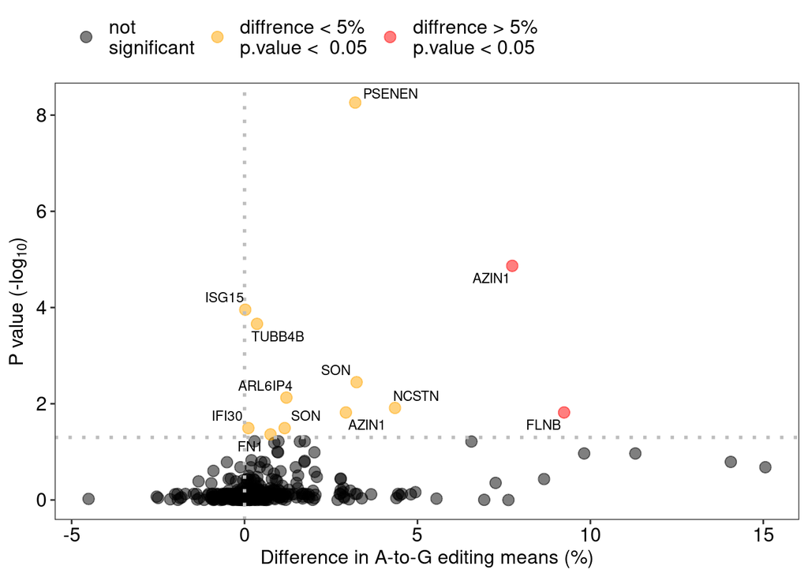

```r
df_all_known_sites_samples_GabaiSites %>%
 ggplot(aes(x = round(100 * (mean_COVID.19  - mean_Control),2),
             y = -log10(`FDR_full:Control:COVID.19`),
             color = ifelse(abs(mean_COVID.19  - mean_Control ) >= 0.05 &
                             `FDR_full:Control:COVID.19` <= 0.05, "red",
                            ifelse(`FDR_full:Control:COVID.19` <= 0.05, "orenge","Black")),
            label = gene
       )) +
  geom_point(alpha=0.5, size =3) +
  scale_color_manual(values = c('black',"orange", "red"),
                     labels =c(paste0('not','\n','significant'),
                                paste0("diffrence < 5%", "\n","p.value <  0.05"),
                               paste0("diffrence > 5%", "\n","p.value < 0.05")),
                     name = element_blank()) +
  theme_bw() +
  theme(panel.grid.major = element_blank(), panel.grid.minor = element_blank())+
  geom_vline(xintercept = c(0),col = "gray",linetype = "dotted",size = 1)+
  geom_hline(yintercept = c(-log10(0.05),-log10(0.05)),col = "gray",linetype = "dotted",size = 1)+
  # geom_hline(yintercept = c(-log10(10e-6),-log10(10e-6)),col = "gray",linetype = "dotted",size = 1)+


  xlab ("Difference in A-to-G editing means (%)")+
  ylab(expression("P value (-log"[10]*")")) +

  font("xlab", size = 12, color = "black",) +
  font("ylab", size = 12, color = "black", ) +
  # font("legendtitle", size = 12, color = "black", face = "bold")+
  font("legendtext", size = 12, color = "black")+
  font("xy.text", size = 12, color = "black")+
  theme(legend.position='top',  legend.justification='left') +

  geom_text_repel(data=df_all_known_sites_samples_GabaiSites %>% filter(`FDR_full:Control:COVID.19` <= 0.05)
                  ,
                size = 3, color="black"
                ) -> plot_p
    plot_p
```

```r
    path_save <- paste0(OUT_DIR,'volcanoPlot_covid19_control_fdr.pdf')
    ggsave(filename = path_save,plot = plot_p,width = 12, height = 10)
```

### Known final results

```r
minimal_diff <- 0.01
max_p.val <- 0.05
max_FDR <- 0.1

FLAG_check_diff <- F
FLAG_check_p.val <- F
FLAG_check_FDR <- T
FLAG_check_FDR_fisher <- F

desired_tests <- allowed_comparisons
```

And now to create vectors out of the values.

For the diffrence:

```r
# if(FLAG_check_diff){
vector_bool_diff <- c(rep(FALSE, nrow(df_all_known_sites_samples_GabaiSites))) #
for (diffrence in grep('diff', colnames(df_all_known_sites_samples_GabaiSites))){
  temp_vec <- paste0('diff:',desired_tests)
  if (colnames(df_all_known_sites_samples_GabaiSites)[diffrence] %in% temp_vec == F){next}

  vector_bool_diff <- vector_bool_diff | (abs(df_all_known_sites_samples_GabaiSites[,diffrence]) >= minimal_diff)

}

vector_bool_diff[is.na(vector_bool_diff)] <- FALSE
sum(vector_bool_diff [vector_bool_diff== TRUE])
```

```
## [1] 108
```

```r
# }
```

For the p.val:

```r
# if(FLAG_check_p.val){
vector_bool_pval <- c(rep(FALSE, nrow(df_all_known_sites_samples_GabaiSites))) #
for (p_val in grep('p_val:', colnames(df_all_known_sites_samples_GabaiSites))){
  temp_vec <- paste0('p_val:',desired_tests)
  if (colnames(df_all_known_sites_samples_GabaiSites)[p_val] %in% temp_vec == F){next}

  vector_bool_pval <- vector_bool_pval | (df_all_known_sites_samples_GabaiSites
                                          [,p_val]<= max_p.val)
}
vector_bool_pval[is.na(vector_bool_pval)] <- FALSE
sum(vector_bool_pval [vector_bool_pval== TRUE])
```

```
## [1] 68
```

```r
# }
```

for the FDR:

```r
# if(FLAG_check_FDR){
vector_bool_fdr <- c(rep(FALSE, nrow(df_all_known_sites_samples_GabaiSites))) #
for (p_val in grep('FDR_full:', colnames(df_all_known_sites_samples_GabaiSites))){
  temp_vec <- paste0('FDR_full:',desired_tests)
  if (colnames(df_all_known_sites_samples_GabaiSites)[p_val] %in% temp_vec == F){next}
  vector_bool_fdr <- vector_bool_fdr | (df_all_known_sites_samples_GabaiSites[,p_val]<= max_FDR)
}
vector_bool_fdr[is.na(vector_bool_fdr)] <- FALSE
sum(vector_bool_fdr [vector_bool_fdr== TRUE])
```

```
## [1] 18
```

```r
# }
```

And now to the fun part: combinations!

```r
vector_bool <- c(rep(TRUE, nrow(df_all_known_sites_samples_GabaiSites)))

if(FLAG_check_diff){vector_bool <- vector_bool & vector_bool_diff}
if(FLAG_check_p.val){vector_bool <- vector_bool & vector_bool_pval}
if(FLAG_check_FDR){vector_bool <- vector_bool & vector_bool_fdr}

sum(vector_bool)
```

```
## [1] 18
```

Now let’s write the table

```r
df_selected_known_sites_samples_GabaiSites <- df_all_known_sites_samples_GabaiSites[vector_bool,]

out_path <- paste0(OUT_DIR,'/',"knownComb_editingSites_allComparison_filtered.csv")
write.csv(df_selected_known_sites_samples_GabaiSites, out_path, row.names = F, quote = F)
```

Now let’s buld the final table

```r
df_summery_table <- df_selected_known_sites_samples_GabaiSites
lst_colnames <- colnames(df_selected_known_sites_samples_GabaiSites)

col_region <- lst_colnames[grep("Region",lst_colnames)]
col_gene <- lst_colnames[grep("gene",lst_colnames)]
# col_annot <- lst_colnames[grep("annot2",lst_colnames)]
col_annot <- lst_colnames[grep("annot",lst_colnames)]
col_strand <- lst_colnames[grep("Strand",lst_colnames)] #GabaiSites
col_Alt <- lst_colnames[grep("Alt",lst_colnames)] #GabaiSites
col_Data <- lst_colnames[grep("Data",lst_colnames)] #GabaiSites

col_mean <- lst_colnames[grep("mean",lst_colnames)]
col_median <- lst_colnames[grep("median",lst_colnames)]

col_diff <- lst_colnames[grep("diff",lst_colnames)]
col_p_val <- lst_colnames[grep("p_val",lst_colnames)]
col_fdr <- lst_colnames[grep("FDR_full",lst_colnames)]
col_pearson <- lst_colnames[grep("pearson",lst_colnames)]
col_GabaiSites <-
df_summery_table <- df_selected_known_sites_samples_GabaiSites[c(col_region, col_gene, col_annot,col_strand,col_Alt,
                                                             col_median,col_mean,col_diff,
                                                             col_pearson,col_p_val,col_fdr, col_Data)]


df_summery_table[c(col_median,col_mean,col_diff)] <- round(df_summery_table[c(col_median,col_mean,col_diff)], digit=3)
df_summery_table[c(col_p_val,col_fdr)] <- signif(df_summery_table[c(col_p_val,col_fdr)], digits=2)

ncol(df_summery_table)
```

```
## [1] 14
```

```r
# allowed_comparisons <- c("female_3:male_3","male_3:male_15","male_3:male_30","male_3:male_45",
                         # "male_15:male_30","male_15:male_45","male_30:male_45")

#prepare the table
df_gather_summery <- df_summery_table[c(col_region, col_gene, col_annot,col_strand,col_Alt, col_Data,col_median, col_mean,col_diff)]
df_gather_summery <- gather(df_gather_summery,"Comparison","Diffrence",
                            -c(col_region, col_gene, col_annot,col_strand,col_Alt, col_Data,col_median, col_mean))
```

[output not shown]

```r
df_gather_summery$Comparison <- gsub("diff:",'',df_gather_summery$Comparison)

df_pearson <- df_summery_table[c(col_region, col_pearson)]
df_pearson <- gather(df_pearson,"Comparison","Pearson",-c(col_region))
df_pearson$Comparison <- gsub("pearson:",'',df_pearson$Comparison)

df_pval <- df_summery_table[c(col_region, col_p_val)]
df_pval <- gather(df_pval,"Comparison","p_val",-c(col_region))
df_pval$Comparison <- gsub("p_val:",'',df_pval$Comparison)

df_fdr <- df_summery_table[c(col_region, col_fdr)]
df_fdr <- gather(df_fdr,"Comparison","fdr",-c(col_region))
df_fdr$Comparison <- gsub("FDR_full:",'',df_fdr$Comparison)

df_comb_summery <- left_join(df_gather_summery,df_pearson, by=c("Region", "Comparison"))
df_comb_summery <- left_join(df_comb_summery,df_pval, by=c("Region", "Comparison"))
df_comb_summery <- left_join(df_comb_summery,df_fdr, by=c("Region", "Comparison"))

df_comb_summery <- df_comb_summery %>% select(c(colnames(df_comb_summery)[!colnames(df_comb_summery) %in% c("expression","Data")],c("Data")))

#Now let's do the same statistics

df_comb_summery <-df_comb_summery[df_comb_summery$fdr <= max_FDR,]



df_comb_summery <- df_comb_summery[!row.names(df_comb_summery) %in%
                                     row.names(df_comb_summery)[grep("^NA",row.names(df_comb_summery))],]




out_path <- paste0(OUT_DIR,'/',"knownComb_editingSites_selectedSites_meansTable.csv")
write.csv(df_comb_summery, out_path, row.names = F, quote = F)


kable(df_comb_summery) %>%
  kable_styling(bootstrap_options = c("striped", "hover", 'condensed'))
```

Region

gene

annot

Strand

Alt

median_Control

median_COVID.19

mean_Control

mean_COVID.19

Comparison

Diffrence

Pearson

p_val

fdr

Data

chr1 1014084

ISG15

nonsynonymous SNV

AG

0.000

0.000

0.002

0.002

Control:COVID.19

0.000

NA

5.0e-07

1.1e-04

NM_005101.3:exon2:c.A104G:p.K35R

chr1 160350197

NCSTN

nonsynonymous SNV

AG

0.000

0.029

0.041

0.085

Control:COVID.19

-0.044

NA

1.2e-04

1.2e-02

NM_015331.2:exon5:c.A529G:p.S177G_NCSTN:NM_001290186.1:exon5:c.A529G:p.S177G_NCSTN:NM_001290184.1:exon6:c.A469G:p.S157G

chr11 65583728

EHBP1L1

nonsynonymous SNV

AG

0.000

0.000

0.000

0.010

Control:COVID.19

-0.010

NA

1.1e-03

6.0e-02

NM_001099409.1:exon9:c.A3056G:p.E1019G

chr12 122981654

ARL6IP4

nonsynonymous SNV

AG

0.000

0.000

0.009

0.021

Control:COVID.19

-0.012

NA

6.4e-05

7.4e-03

NM_001278380.1:exon3:c.A211G:p.S71G_ARL6IP4:NM_001278378.1:exon3:c.A772G:p.S258G_ARL6IP4:NM_016638.3:exon3:c.A739G:p.S247G_ARL6IP4:NM_001002251.2:exon3:c.A772G:p.S258G_ARL6IP4:NM_001002252.2:exon3:c.A739G:p.S247G_ARL6IP4:NM_018694.3:exon3:c.A796G:p.S266G_ARL6IP4:NM_001278379.1:exon3:c.A379G:p.S127G

chr17 27648981

LGALS9

stoploss

AG

0.000

0.000

0.002

0.005

Control:COVID.19

-0.003

NA

1.3e-03

6.0e-02

NM_009587.2:exon11:c.A1067G:p.X356W_LGALS9:NM_002308.3:exon10:c.A971G:p.X324W

chr17 38722707

MLLT6

nonsynonymous SNV

AG

0.000

0.000

0.004

0.013

Control:COVID.19

-0.009

NA

1.7e-03

6.5e-02

NM_005937.3:exon18:c.A2822G:p.Q941R

chr19 18173937

IFI30

synonymous SNV

AG

0.040

0.071

0.070

0.087

Control:COVID.19

-0.017

NA

1.3e-03

6.0e-02

NM_006332.4:exon1:c.A96G:p.L32L

chr19 18177741

IFI30

nonsynonymous SNV

AG

0.000

0.013

0.025

0.026

Control:COVID.19

-0.001

NA

5.0e-04

3.2e-02

NM_006332.4:exon6:c.A667G:p.T223A

chr19 35746748

PSENEN

nonsynonymous SNV

AG

0.000

0.018

0.012

0.044

Control:COVID.19

-0.032

NA

0.0e+00

0.0e+00

NM_001281532.1:exon4:c.A207G:p.I69M_PSENEN:NM_172341.2:exon4:c.A207G:p.I69M

chr2 215376615

FN1

nonsynonymous SNV

AG

0.000

0.000

0.000

0.008

Control:COVID.19

-0.008

NA

7.4e-04

4.3e-02

NM_212476.2:exon34:c.A5227G:p.S1743G_FN1:NM_212482.2:exon36:c.A5770G:p.S1924G_FN1:NM_212478.2:exon35:c.A5497G:p.S1833G_FN1:NM_001306130.1:exon35:c.A5500G:p.S1834G_FN1:NM_002026.3:exon35:c.A5497G:p.S1833G_FN1:NM_001306132.1:exon34:c.A5227G:p.S1743G_FN1:NM_001306131.1:exon34:c.A5227G:p.S1743G_FN1:NM_001306129.1:exon36:c.A5770G:p.S1924G_FN1:NM_212474.2:exon34:c.A5227G:p.S1743G

chr21 33550530

SON

synonymous SNV

AG

0.000

0.000

0.003

0.014

Control:COVID.19

-0.012

NA

4.9e-04

3.2e-02

NM_138927.2:exon3:c.A1299G:p.T433T_SON:NM_001291411.1:exon3:c.A1299G:p.T433T_SON:NM_032195.2:exon3:c.A1299G:p.T433T

chr21 33550853

SON

nonsynonymous SNV

AG

0.000

0.008

0.017

0.033

Control:COVID.19

-0.016

NA

1.5e-03

6.1e-02

NM_138927.2:exon3:c.A1622G:p.E541G_SON:NM_001291411.1:exon3:c.A1622G:p.E541G_SON:NM_032195.2:exon3:c.A1622G:p.E541G

chr21 33551013

SON

synonymous SNV

AG

0.056

0.095

0.068

0.100

Control:COVID.19

-0.032

NA

2.5e-05

3.6e-03

NM_138927.2:exon3:c.A1782G:p.L594L_SON:NM_001291411.1:exon3:c.A1782G:p.L594L_SON:NM_032195.2:exon3:c.A1782G:p.L594L

chr3 58156064

FLNB

nonsynonymous SNV

AG

0.137

0.246

0.174

0.266

Control:COVID.19

-0.092

NA

1.8e-04

1.5e-02

NM_001457.3:exon41:c.A6877G:p.M2293V_FLNB:NM_001164319.1:exon40:c.A6805G:p.M2269V_FLNB:NM_001164317.1:exon42:c.A6970G:p.M2324V_FLNB:NM_001164318.1:exon41:c.A6844G:p.M2282V

chr4 57110068

IGFBP7

nonsynonymous SNV

AG

0.148

0.189

0.153

0.219

Control:COVID.19

-0.066

NA

1.5e-03

6.1e-02

NM_001553.2:exon1:c.A284G:p.K95R_IGFBP7:NM_001253835.1:exon1:c.A284G:p.K95R

chr8 102829408

AZIN1

nonsynonymous SNV

AG

0.103

0.194

0.126

0.204

Control:COVID.19

-0.077

NA

0.0e+00

1.4e-05

NM_015878.5:exon12:c.A1099G:p.S367G_AZIN1:NM_148174.3:exon11:c.A1099G:p.S367G

chr8 102829409

AZIN1

synonymous SNV

AG

0.011

0.035

0.036

0.065

Control:COVID.19

-0.029

NA

1.9e-04

1.5e-02

NM_015878.5:exon12:c.A1098G:p.E366E_AZIN1:NM_148174.3:exon11:c.A1098G:p.E366E

chr9 137243170

TUBB4B

nonsynonymous SNV

AG

0.000

0.000

0.002

0.006

Control:COVID.19

-0.004

NA

1.2e-06

2.2e-04

NM_006088.5:exon4:c.A952G:p.R318G

All sites

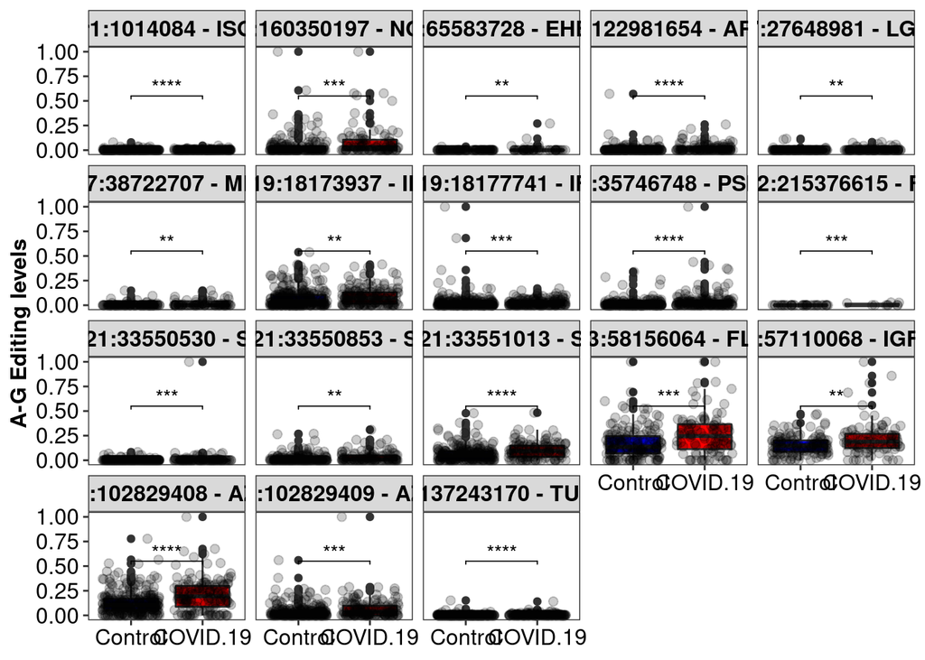

```r
df_selected_known_sites_samples_GabaiSites %>%
  # filter(abs(`diff:Control:COVID.19`) >=0.05 ) %>%
  select("Chr","End", "annot", "gene",
         grep("_[A-Z,0-9]*_BaseCount.A.C.G.T.",names(.))) %>%
  gather("Sample","Editing", -c("Chr","End", "annot", "gene")) %>%
  mutate(Sample = gsub("_BaseCount.A.C.G.T.","",Sample)) %>%
  separate(Sample,into = c("Group","Run"),sep ="_") %>%
  mutate(label = paste0(Chr,":",End," - ",gene)) %>%
  ggplot(
               aes(y=Editing, x=Group))+
  geom_boxplot(aes(fill=Group)) +  geom_jitter( size=2, alpha = 0.2)+
  facet_wrap(  .~label )+
  themes_ggplot+ ylab("A-G Editing levels")+ xlab ("Group")+ scale_fill_discrete(name = "Group:")+
  expand_limits(y = 0) + scale_fill_manual(values=c("blue", "red"))+
  theme(axis.title.x = element_blank())+ theme(legend.position = "none")+
  stat_compare_means(method = "wilcox.test", comparisons = list(c("Control", "COVID.19")),
                     label = "p.signif",
                     label.y = 0.5
                     ) -> plot
plot
```

```r
out_path <- paste0(OUT_DIR,'/',"known_selectedSites.pdf")
ggsave(out_path, plot, width = 16, height = 10)
```

strong sites

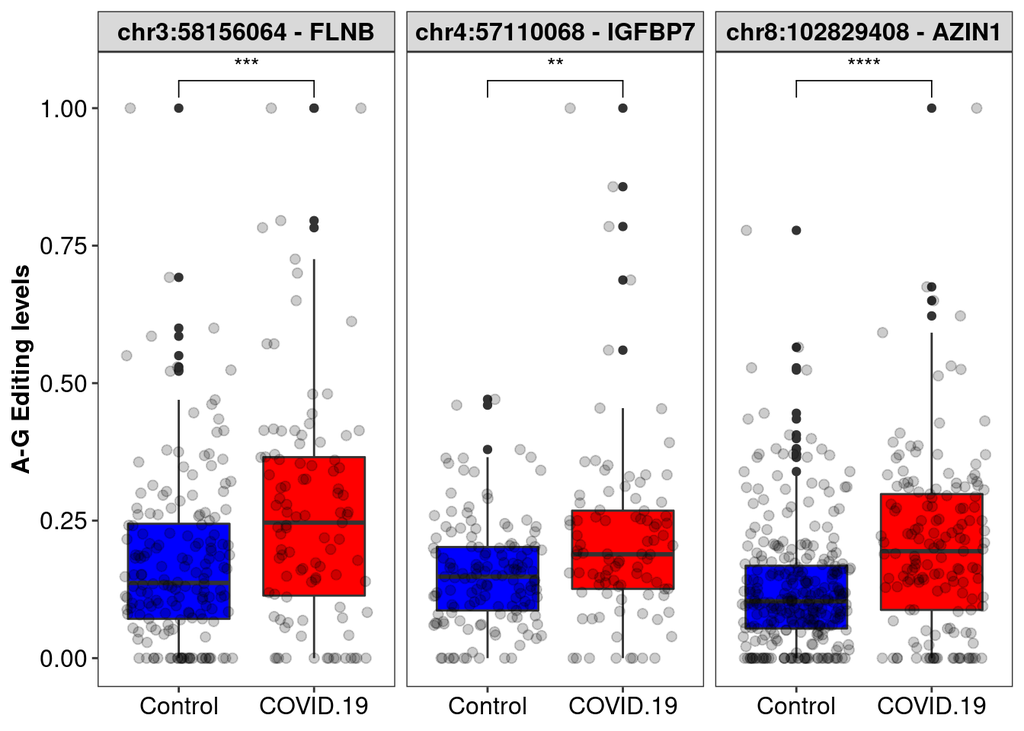

```r
df_selected_known_sites_samples_GabaiSites %>%
  filter(abs(`diff:Control:COVID.19`) >=0.05 ) %>%
  select("Chr","End", "annot", "gene",
         grep("_[A-Z,0-9]*_BaseCount.A.C.G.T.",names(.))) %>%
  gather("Sample","Editing", -c("Chr","End", "annot", "gene")) %>%
  mutate(Sample = gsub("_BaseCount.A.C.G.T.","",Sample)) %>%
  separate(Sample,into = c("Group","Run"),sep ="_") %>%
  mutate(label = paste0(Chr,":",End," - ",gene)) %>%
  ggplot(
               aes(y=Editing, x=Group))+
  geom_boxplot(aes(fill=Group)) +  geom_jitter( size=2, alpha = 0.2)+
  facet_wrap(  .~label )+
  themes_ggplot+ ylab("A-G Editing levels")+ xlab ("Group")+ scale_fill_discrete(name = "Group:")+
  expand_limits(y = 0) + scale_fill_manual(values=c("blue", "red"))+
  theme(axis.title.x = element_blank())+ theme(legend.position = "none")+
  stat_compare_means(method = "wilcox.test", comparisons = list(c("Control", "COVID.19")),
                     label = "p.signif",
                     ) -> plot
plot
```

```r
out_path <- paste0(OUT_DIR,'/',"known_selectedSites_strong.pdf")
ggsave(out_path, plot, width = 10, height = 6)
```